# The Life Changing Magic of Tidying Up: 'tidyverse' basics

Carey Lab Meeting  
March 27, 2018

### What is 'tidyverse'?

- Collection of R packages designed for data science
- Packages share an underlying:
  - Design philosophy
  - Grammar
  - Data structure

[figure not shown]

### What is 'tidyverse'?

**Core Packages:** auto-load with library(tidyverse)

- ggplot2: graphics
- dplyr: data manipulation
- tidyr: tidy data
- readr: read & parse data files
- purrr: functions & vectors
- tibble: data frames reimagined

[figure not shown]

### Why use tidyverse?

- Unified grammar and structure
- Tidy code easier to write, read, maintain than base R counterparts (+ is almost always faster to run!)
- Transparent & reproducible workflows

[figure not shown]

### Style principles

*“Good coding style is like correct punctuation: you can manage without it, butitsuremakesthingseasiertoread.”*

**Three essentials to start:**

1. Use informative file names
   - variable names = nouns; function names = verbs
2. Load all packages at the beginning of a script
3. Limit your code to 80 characters per line

Lots more that's worth a read at: [tidyverse style guide](http://style.tidyverse.org)

### Tidy data principles

1. Each variable in its own column
2. Each observation in its own row
3. Each value in its own cell

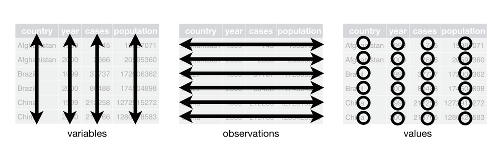

### Reading data

- read_csv() reads in .csv files as a tibble

**Tibble benefits:**

- ~10x faster than read.csv()
- Assumes 1st row is column headings by default (no more header = TRUE)
- Doesn't change input type: parses datetime, characters, etc.
  - No more stringsAsFactors = FALSE
- Doesn't alter variable names (e.g., “column name” does not become “column.name”)
- Doesn't assign row.names()

### Reading data

```r
library(tidyverse)
myData <- read_csv("demo_data.csv")
```

```
# A tibble: 6 x 4
  City        DATE         PRCP  TAVG
  <chr>       <date>      <dbl> <int>
1 Los Angeles 2017-01-01 0.        50
2 Miami       2017-01-01 0.        76
3 Fairbanks   2017-01-01 0.        12
4 Minneapolis 2017-01-01 0.        26
5 Roanoke     2017-01-01 0.0300    46
6 Los Angeles 2017-01-02 0.        53
```

Notice that the DATE column automatically parsed as a date  
**No need** for the as.Date(myData$DATE) command!

### Data transformation

- **filter()**
- **arrange()**
- **select()**
- **mutate()**
- **summarise()**

[figure not shown]

### Pipes: Link commands together

- Use %>% when you find yourself
  - **composing multiple functions in a nested call**, or
  - **creating intermediate objects that you don't care about saving**
- Put each verb on its own line
  - This makes it simpler to rearrange them later, and makes it harder to overlook a step

%>% should always have *a space before it*  
and *a new line after it*

[figure not shown]

### Core commands: filter()

- filter() can include multiple arguments with Boolean operations

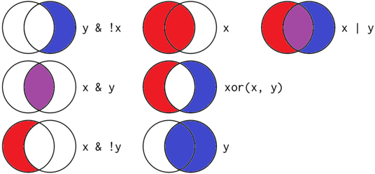

- Select multiple items from within a string:
  - x %in% c('y', 'z')
- filter() excludes both FALSE and NA values by default

### Core commands: filter()

```r
SEast <- filter(myData, City == "Roanoke" | City == "Miami")
```

```
# A tibble: 6 x 4
  City    DATE         PRCP  TAVG
  <chr>   <date>      <dbl> <int>
1 Miami   2017-01-01 0.        76
2 Roanoke 2017-01-01 0.0300    46
3 Miami   2017-01-02 0.        80
4 Roanoke 2017-01-02 0.0900    47
5 Miami   2017-01-03 0.690     80
6 Roanoke 2017-01-03 0.510     44
```

OR filter using a list

```r
SEast <- filter(myData, City %in% c("Roanoke", "Miami"))
```

```
# A tibble: 6 x 4
  City    DATE         PRCP  TAVG
  <chr>   <date>      <dbl> <int>
1 Miami   2017-01-01 0.        76
2 Roanoke 2017-01-01 0.0300    46
3 Miami   2017-01-02 0.        80
4 Roanoke 2017-01-02 0.0900    47
5 Miami   2017-01-03 0.690     80
6 Roanoke 2017-01-03 0.510     44
```

### Core commands: select()

- Select (or anti-select) columns by name
- Or use a helper function within select:
  - starts_with(“abc”): matches names that begin with “abc”
  - ends_with(“xyz”): matches names that end with “xyz”
  - contains(“ijk”): matches names that contain “ijk”
  - matches(“(.)\1”): selects variables that match a regular expression This one matches any variables that contain repeated characters

### Core commands: select()

You can select columns by name without quotes

```r
temps <- select(myData, City, DATE, TAVG)
names(temps)
```

```
[1] "City" "DATE" "TAVG"
```

Or, rather than selecting all but *one* column,  
“anti-select” the one to drop

```r
temps <- select(myData, -PRCP)
names(temps)
```

```
[1] "City" "DATE" "TAVG"
```

### Core commands: mutate()

Oops, our data is in Fahrenheit! Need a column with Celsius!

```r
temps <- temps %>%
  rename(Temp_F = TAVG) %>%
  mutate(Temp_C = ((Temp_F - 32) * (5/9)))
```

```
# A tibble: 6 x 4
  City        DATE       Temp_F Temp_C
  <chr>       <date>      <int>  <dbl>
1 Los Angeles 2017-01-01     50  10.0
2 Miami       2017-01-01     76  24.4
3 Fairbanks   2017-01-01     12 -11.1
4 Minneapolis 2017-01-01     26  -3.33
5 Roanoke     2017-01-01     46   7.78
6 Los Angeles 2017-01-02     53  11.7
```

### Core commands: summarise()

- Collapse your dataframe into a single row
- Most useful when paired with group_by() for grouped summaries
- Includes basic summary metrics
  - n(), n_distinct()
  - mean(), median()
  - sd()
  - sum()
- **Important note:** NA values are *not excluded* by default
  - Include na.rm = TRUE in each clause to exclude NA's

### Core commands: summarise()

Let's find out the 2017 mean temperature in each city:

```r
annual <- temps %>%
  mutate(year = lubridate::year(DATE)) %>%
  filter(year == 2017) %>%
  group_by(City, year) %>%
  summarise(Mean = mean(Temp_C, na.rm = T))

annual
```

```
# A tibble: 5 x 3
# Groups:   City [?]
  City         year   Mean
  <chr>       <dbl>  <dbl>
1 Fairbanks   2017.  -1.10
2 Los Angeles 2017.  17.9
3 Miami       2017.  25.9
4 Minneapolis 2017.   9.26
5 Roanoke     2017.  15.0
```

### Core commands: spread() & gather()

**spread**(long, column_with_names, column_with_values)

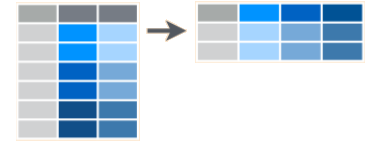

**gather**(wide, new_names, new_values, A:Z, factor_key = T)

- A:Z: Names of source columns that contain values
- factor_key: Treat the new key column as a factor (instead of character vector)

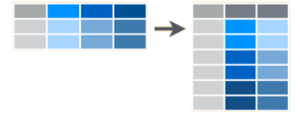

### Core commands: spread() & gather()

Maybe we want to compare Miami and Roanoke temps each day:

```r
dataWide <- myData %>%
  select(-PRCP) %>%
  filter(City %in% c('Roanoke', 'Miami')) %>%
  spread(City, TAVG)

dataWide
```

```
# A tibble: 430 x 3
   DATE       Miami Roanoke
   <date>     <int>   <int>
 1 2017-01-01    76      46
 2 2017-01-02    80      47
 3 2017-01-03    80      44
 4 2017-01-04    76      51
 5 2017-01-05    74      34
 6 2017-01-06    72      31
 7 2017-01-07    78      24
 8 2017-01-08    59      16
 9 2017-01-09    61      16
10 2017-01-10    70      26
# ... with 420 more rows
```

### Core commands: separate() & unite()

- Default split wherever there is a non-alphanumeric character
  - Can manually set split with sep = “ ”

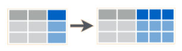

**unite**(new_column, A, B, sep = “”)

- Use sep = “_” or similar to add seperator in new column

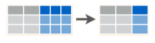

### Writing data

- write_csv() writes a .csv file

**Benefits:**

- ~2x faster than write.csv() for large files
- Saves dates and date-times in ISO-8601 format with UTC timezone
- No need for row.names = FALSE

[figure not shown]

### Bonus packages

**lubridate**

- Easily work with dates!
  - Parsing of date-times: ymd(), ymd_hms()
  - Functions to get and set components of a date-time: year(), month(), mday()
  - Learn more: [lubridate cheat sheet](https://github.com/rstudio/cheatsheets/raw/master/lubridate.pdf)

[figure not shown]

### lubridate

Extract years and months painlessly from DateTime columns

*Note*: Date parts are parsed to double by default,  
but you can specify factor() within the mutate command

```r
library(lubridate)

temps <- temps %>%
  mutate(year = year(DATE), month = factor(month(DATE)))
```

```
# A tibble: 6 x 6
  City        DATE       Temp_F Temp_C  year month
  <chr>       <date>      <int>  <dbl> <dbl> <fct>
1 Los Angeles 2017-01-01     50  10.0  2017. 1
2 Miami       2017-01-01     76  24.4  2017. 1
3 Fairbanks   2017-01-01     12 -11.1  2017. 1
4 Minneapolis 2017-01-01     26  -3.33 2017. 1
5 Roanoke     2017-01-01     46   7.78 2017. 1
6 Los Angeles 2017-01-02     53  11.7  2017. 1
```

### Bonus packages

**broom**

- Convert statistical analysis objects from R into tidy data frames, so that they can more easily be combined, reshaped and otherwise processed with tools like dplyr, tidyr and ggplot2

[figure not shown]

### broom: Zip through analyses across groups!

For example, we can fit a regression for each city with one command…

```r
temp_correlations <- temps %>%
  group_by(City) %>%
  do(broom::tidy(lm(.$Temp_C ~ .$DATE)))
```

```
# A tibble: 6 x 6
# Groups:   City [3]
  City        term          estimate std.error statistic   p.value
  <chr>       <chr>            <dbl>     <dbl>     <dbl>     <dbl>
1 Fairbanks   (Intercept)  142.      110.           1.30 0.196
2 Fairbanks   .$DATE        -0.00839   0.00631     -1.33 0.185
3 Los Angeles (Intercept)  -78.5      23.2         -3.39 0.000776
4 Los Angeles .$DATE         0.00553   0.00133      4.14 0.0000416
5 Miami       (Intercept)   56.9      25.9          2.20 0.0287
6 Miami       .$DATE        -0.00182   0.00149     -1.22 0.224
```

### Additional resources

- [R for Data Science](http://r4ds.had.co.nz/)
- [RStudio cheat sheets](https://www.rstudio.com/resources/cheatsheets/)
- [A gRadual intRoduction to the tidyverse](https://github.com/Cascadia-R/gRadual-intRoduction-tidyverse?utm_content=buffer193d5&utm_medium=social&utm_source=twitter.com&utm_campaign=buffer): Self-guided workshop
- [Switching from Base R to tidyverse](http://www.significantdigits.org/2017/10/switching-from-base-r-to-tidyverse/): List of equivalent commands

[figure not shown]

### # Comments about comments

*In code, use comments to explain the “why” not the “what” or “how”*

- Use comments to record important findings and analysis decisions
- If you need comments to explain what your code is doing, consider rewriting your code to be clearer
- If you discover that you have more comments than code, considering switching to RMarkdown

From [Tidyverse Style Guide](http://style.tidyverse.org/)

[figure not shown]